# PEC1_análisis_datos_ómicos

Elisabet Nebot

2025-03-30

#### **Presentación y objetivos**

Esta PEC completa la introducción a las ómicas mediante un ejercicio de repaso y ampliación que nos permite trabajar con algunas de las herramientas que hemos introducido durante el curso: Bioconductor y la exploración multivariante de datos. Para llevarla a cabo, previamente debéis estar familiarizados con:

- Las tecnologías ómicas.
- Bioconductor y las clases que se utilizan para almacenar datos ómicos, como los `expressionSets`.
- Git como herramienta de control de versiones, así como GitHub.
- Las herramientas estadísticas de exploración de datos introducidas al final del primer reto.

El objetivo de esta PEC es que planifiquéis y ejecutéis una versión simplificada del proceso de análisis de datos ómicos, a la vez que practicáis con algunas de las herramientas y métodos que hemos trabajado durante el primer reto.

##### **Cargando paquetes necesarios**

```r
library(readr);library(SummarizedExperiment);library(tidyverse); library(xfun); library(ggfortify); library(ggrepel)
```

##### **Ejercicio 1. Seleccionad y descargad un dataset de metabolómica, que podéis obtener de metabolomicsWorkbench o de este repositorio de GitHub.**

```r
human_cachexia <- read_csv("Data/human_cachexia.csv")
str(human_cachexia)
```

```
## spc_tbl_ [77 × 65] (S3: spec_tbl_df/tbl_df/tbl/data.frame)
##  $ Patient ID                : chr [1:77] "PIF_178" "PIF_087" "PIF_090" "NETL_005_V1" ...
##  $ Muscle loss               : chr [1:77] "cachexic" "cachexic" "cachexic" "cachexic" ...
##  $ 1,6-Anhydro-beta-D-glucose: num [1:77] 40.9 62.2 270.4 154.5 22.2 ...
##  $ 1-Methylnicotinamide      : num [1:77] 65.4 340.4 64.7 53 73.7 ...
##  $ 2-Aminobutyrate           : num [1:77] 18.7 24.3 12.2 172.4 15.6 ...
##  $ 2-Hydroxyisobutyrate      : num [1:77] 26.1 41.7 65.4 74.4 83.9 ...
##  $ 2-Oxoglutarate            : num [1:77] 71.5 67.4 23.8 1199.9 33.1 ...
##  $ 3-Aminoisobutyrate        : num [1:77] 1480.3 116.8 14.3 555.6 29.7 ...
##  $ 3-Hydroxybutyrate         : num [1:77] 56.83 43.82 5.64 175.91 76.71 ...
##  $ 3-Hydroxyisovalerate      : num [1:77] 10.1 79.8 23.3 25 69.4 ...
##  $ 3-Indoxylsulfate          : num [1:77] 567 369 665 412 166 ...
##  $ 4-Hydroxyphenylacetate    : num [1:77] 120.3 432.7 292.9 214.9 97.5 ...
##  $ Acetate                   : num [1:77] 126.5 212.7 314.2 37.3 407.5 ...
##  $ Acetone                   : num [1:77] 9.49 11.82 4.44 206.44 44.26 ...
##  $ Adipate                   : num [1:77] 38.1 327 131.6 144 15 ...
##  $ Alanine                   : num [1:77] 314 871 464 590 1119 ...
##  $ Asparagine                : num [1:77] 159.2 157.6 89.1 273.1 42.5 ...
##  $ Betaine                   : num [1:77] 110 245 117 279 392 ...
##  $ Carnitine                 : num [1:77] 265.1 120.3 25 200.3 84.8 ...
##  $ Citrate                   : num [1:77] 3714 2618 863 13630 854 ...
##  $ Creatine                  : num [1:77] 196.4 212.7 221.4 85.6 105.6 ...
##  $ Creatinine                : num [1:77] 16482 15835 24588 20952 6768 ...
##  $ Dimethylamine             : num [1:77] 633 608 735 1064 242 ...
##  $ Ethanolamine              : num [1:77] 645 488 407 821 365 ...
##  $ Formate                   : num [1:77] 441 252 250 469 114 ...
##  $ Fucose                    : num [1:77] 337 198.3 186.8 407.5 26.1 ...
##  $ Fumarate                  : num [1:77] 7.69 18.92 7.1 96.54 19.69 ...
##  $ Glucose                   : num [1:77] 395 8691 1353 863 6836 ...
##  $ Glutamine                 : num [1:77] 871 602 302 1686 433 ...
##  $ Glycine                   : num [1:77] 2039 1108 620 5064 395 ...
##  $ Glycolate                 : num [1:77] 685.4 652 141.2 70.8 26.6 ...
##  $ Guanidoacetate            : num [1:77] 154 110 183 103 53 ...
##  $ Hippurate                 : num [1:77] 4582 1737 4316 757 1153 ...
##  $ Histidine                 : num [1:77] 925 846 284 1043 327 ...
##  $ Hypoxanthine              : num [1:77] 97.5 82.3 114.4 223.6 66.7 ...
##  $ Isoleucine                : num [1:77] 5.58 8.17 9.3 37.71 40.04 ...
##  $ Lactate                   : num [1:77] 107 369 750 369 3641 ...
##  $ Leucine                   : num [1:77] 42.1 77.5 31.5 103.5 101.5 ...
##  $ Lysine                    : num [1:77] 146.9 284.3 97.5 290 122.7 ...
```

[output cut: 80 more lines]

```
##   ..   Threonine = col_double(),
##   ..   Trigonelline = col_double(),
##   ..   `Trimethylamine N-oxide` = col_double(),
##   ..   Tryptophan = col_double(),
##   ..   Tyrosine = col_double(),
##   ..   Uracil = col_double(),
##   ..   Valine = col_double(),
##   ..   Xylose = col_double(),
##   ..   `cis-Aconitate` = col_double(),
##   ..   `myo-Inositol` = col_double(),
##   ..   `trans-Aconitate` = col_double(),
##   ..   `pi-Methylhistidine` = col_double(),
##   ..   `tau-Methylhistidine` = col_double()
##   .. )
##  - attr(*, "problems")=<externalptr>
```

##### **Explicación:**

El dataset es un conjunto de datos de metabolómica, que mide la concentración de 63 metabolitos en 77 pacientes, diferenciados en dos grupos: pacientes con caquexia y controles sin la enfermedad. Cada fila representa un paciente y cada columna corresponde a una variable, incluyendo la identidad del paciente, la presencia o ausencia de pérdida muscular y los niveles de metabolitos en sus muestras biológicas.

La elección de este dataset se basa en el interés por comprender las alteraciones metabólicas asociadas a la caquexia, una condición caracterizada por una pérdida severa de masa muscular que afecta la calidad de vida y el pronóstico de los pacientes.

##### **Ejercicio 2. Cread un objeto de clase SummarizedExperiment que contenga los datos y los metadatos (información acerca del dataset, sus filas y columnas). La clase SummarizedExperiment es una extensión de ExpressionSet, utilizada por muchas aplicaciones y bases de datos (como es el caso de metabolomicsWorkbench).#¿Cuáles son sus principales diferencias con la clase ExpressionSet?**

##### 2.1 Creación de los parámetros de un SummarizedExperiment:

```r
# Se seleccionan las dos columnas que contienen la información de los pacientes (metadata)
metadata_cols <- 1:2

# Se crea la matriz de datos de expresión (excluyendo las columnas de metadata)
expression_data <- as.matrix(human_cachexia[, -(metadata_cols)])

# Se asignan los nombres de las filas con los IDs de los pacientes
rownames(expression_data) <- human_cachexia$`Patient ID`

# Se crea los metadatos de las muestras (colData), con los IDs de pacientes como nombres de fila
colData_metadata <- human_cachexia[, metadata_cols] %>%
  column_to_rownames(var = "Patient ID")

# Descripción del dataset (metadata general)
descripcion_estudio <- "Cachexia is a complex metabolic syndrome associated with an underlying illness (such as cancer) and characterized by loss of muscle with or without loss of fat mass (Evans et al., 2008). A total of 77 urine samples were collected, 47 from patients with cachexia and 30 from control patients (from the 'specmine.datasets' R package)."

# Creación del objeto SummarizedExperiment
se_object <- SummarizedExperiment(
  assays = list(counts = t(expression_data)),  # Matriz de datos
  colData = colData_metadata, # Metadatos de pacientes
  metadata = list(description = descripcion_estudio))  #  Descripción del estudio

se_object
```

```
## class: SummarizedExperiment
## dim: 63 77
## metadata(1): description
## assays(1): counts
## rownames(63): 1,6-Anhydro-beta-D-glucose 1-Methylnicotinamide ...
##   pi-Methylhistidine tau-Methylhistidine
## rowData names(0):
## colnames(77): PIF_178 PIF_087 ... NETL_003_V1 NETL_003_V2
## colData names(1): Muscle loss
```

```r
assay(se_object) # se visualiza la matriz de datos
```

```
##                             PIF_178  PIF_087  PIF_090 NETL_005_V1 PIF_115
## 1,6-Anhydro-beta-D-glucose    40.85    62.18   270.43      154.47   22.20
## 1-Methylnicotinamide          65.37   340.36    64.72       52.98   73.70
## 2-Aminobutyrate               18.73    24.29    12.18      172.43   15.64
## 2-Hydroxyisobutyrate          26.05    41.68    65.37       74.44   83.93
## 2-Oxoglutarate                71.52    67.36    23.81     1199.91   33.12
## 3-Aminoisobutyrate          1480.30   116.75    14.30      555.57   29.67
## 3-Hydroxybutyrate             56.83    43.82     5.64      175.91   76.71
## 3-Hydroxyisovalerate          10.07    79.84    23.34       25.03   69.41
## 3-Indoxylsulfate             566.80   368.71   665.14      411.58  165.67
## 4-Hydroxyphenylacetate       120.30   432.68   292.95      214.86   97.51
## Acetate                      126.47   212.72   314.19       37.34  407.48
## Acetone                        9.49    11.82     4.44      206.44   44.26
## Adipate                       38.09   327.01   131.63      144.03   15.03
## Alanine                      314.19   871.31   464.05      589.93 1118.79
## Asparagine                   159.17   157.59    89.12      273.14   42.52
## Betaine                      109.95   244.69   116.75      278.66  391.51
## Carnitine                    265.07   120.30    25.03      200.34   84.77
## Citrate                     3714.50  2617.57   862.64    13629.61  854.06
## Creatine                     196.37   212.72   221.41       85.63  105.64
## Creatinine                 16481.60 15835.35 24587.66    20952.22 6768.26
## Dimethylamine                632.70   607.89   735.10     1064.22  242.26
## Ethanolamine                 645.48   487.85   407.48      820.57  365.04
## Formate                      441.42   252.14   249.64      468.72  114.43
## Fucose                       336.97   198.34   186.79      407.48   26.05
## Fumarate                       7.69    18.92     7.10       96.54   19.69
## Glucose                      395.44  8690.62  1352.89      862.64 6836.29
## Glutamine                    871.31   601.85   301.87     1685.81  432.68
## Glycine                     2038.56  1107.65   620.17     5064.45  395.44
## Glycolate                    685.40   651.97   141.17       70.81   26.58
## Guanidoacetate               154.47   109.95   183.09      102.51   52.98
## Hippurate                   4582.50  1737.15  4315.64      757.48 1152.86
## Histidine                    925.19   845.56   284.29     1043.15  327.01
## Hypoxanthine                  97.51    82.27   114.43      223.63   66.69
## Isoleucine                     5.58     8.17     9.30       37.71   40.04
## Lactate                      106.70   368.71   749.95      368.71 3640.95
## Leucine                       42.10    77.48    31.50      103.54  101.49
## Lysine                       146.94   284.29    97.51      290.03  122.73
## Methylamine                   52.46    23.57    18.73       48.91   27.94
## Methylguanidine                9.97     7.69     4.66      141.17    5.31
```

[output cut: 1097 more lines]

```
## Tartrate                         30.57
## Taurine                         113.30
## Threonine                        32.46
## Trigonelline                    154.47
## Trimethylamine N-oxide          403.43
## Tryptophan                       27.66
## Tyrosine                         23.57
## Uracil                            9.58
## Valine                           10.59
## Xylose                           19.89
## cis-Aconitate                    58.56
## myo-Inositol                     24.29
## trans-Aconitate                  13.07
## pi-Methylhistidine               83.93
## tau-Methylhistidine              27.39
```

```r
colData(se_object) #se visualiza la ID de los pacientes y el factor 'Muscle.loss'
```

```
## DataFrame with 77 rows and 1 column
##              Muscle loss
##              <character>
## PIF_178         cachexic
## PIF_087         cachexic
## PIF_090         cachexic
## NETL_005_V1     cachexic
## PIF_115         cachexic
## ...                  ...
## NETCR_019_V2     control
## NETL_012_V1      control
## NETL_012_V2      control
## NETL_003_V1      control
## NETL_003_V2      control
```

```r
metadata(se_object) # se visualiza la descripción del estudio
```

```
## $description
## [1] "Cachexia is a complex metabolic syndrome associated with an underlying illness (such as cancer) and characterized by loss of muscle with or without loss of fat mass (Evans et al., 2008). A total of 77 urine samples were collected, 47 from patients with cachexia and 30 from control patients (…
```

```r
save(se_object, file = "SummarizedExperiment_data.Rda")
```

##### **Ejercicio 3. Llevad a cabo un análisis exploratorio que os proporcione una visión general del dataset en la línea de lo que hemos visto en las actividades de este reto.**

```r
# Análisis univariantes

dim(se_object) # dimensiones de la matriz
```

```
## [1] 63 77
```

```r
names(se_object) # nombres de metabolitos que han sido medidos en cada muestra
```

```
##  [1] "1,6-Anhydro-beta-D-glucose" "1-Methylnicotinamide"
##  [3] "2-Aminobutyrate"            "2-Hydroxyisobutyrate"
##  [5] "2-Oxoglutarate"             "3-Aminoisobutyrate"
##  [7] "3-Hydroxybutyrate"          "3-Hydroxyisovalerate"
##  [9] "3-Indoxylsulfate"           "4-Hydroxyphenylacetate"
## [11] "Acetate"                    "Acetone"
## [13] "Adipate"                    "Alanine"
## [15] "Asparagine"                 "Betaine"
## [17] "Carnitine"                  "Citrate"
## [19] "Creatine"                   "Creatinine"
## [21] "Dimethylamine"              "Ethanolamine"
## [23] "Formate"                    "Fucose"
## [25] "Fumarate"                   "Glucose"
## [27] "Glutamine"                  "Glycine"
## [29] "Glycolate"                  "Guanidoacetate"
```

[output cut: 17 more lines]

```r
summary(assay(se_object, "counts")) # estadística descriptiva de los niveles de cada metabolito en los diferentes pacientes
```

```
##     PIF_178            PIF_087            PIF_090          NETL_005_V1
##  Min.   :    5.58   Min.   :    7.69   Min.   :    4.44   Min.   :   25.03
##  1st Qu.:   52.72   1st Qu.:   78.66   1st Qu.:   31.50   1st Qu.:  102.51
##  Median :  154.47   Median :  208.51   Median :  141.17   Median :  247.15
##  Mean   :  699.86   Mean   :  708.30   Mean   :  771.79   Mean   : 1021.28
##  3rd Qu.:  416.24   3rd Qu.:  412.10   3rd Qu.:  308.03   3rd Qu.:  673.71
##  Max.   :16481.60   Max.   :15835.35   Max.   :24587.66   Max.   :20952.22
##     PIF_115           PIF_110          NETL_019_V1       NETCR_014_V1
##  Min.   :   4.53   Min.   :    5.05   Min.   :   2.10   Min.   :   1.73
##  1st Qu.:  44.26   1st Qu.:   35.34   1st Qu.:  26.73   1st Qu.:   7.14
##  Median :  84.77   Median :  113.30   Median :  91.84   Median :  18.17
##  Mean   : 441.22   Mean   :  537.48   Mean   : 400.85   Mean   :  82.77
##  3rd Qu.: 196.62   3rd Qu.:  325.58   3rd Qu.: 223.63   3rd Qu.:  52.52
##  Max.   :6836.29   Max.   :15677.78   Max.   :8022.46   Max.   :2208.35
##   NETCR_014_V2        PIF_154         NETL_022_V1       NETL_022_V2
##  Min.   :   2.41   Min.   :   9.12   Min.   :   4.26   Min.   :    7.17
##  1st Qu.:  14.63   1st Qu.:  43.82   1st Qu.:  31.98   1st Qu.:   38.77
##  Median :  39.65   Median : 117.92   Median :  83.93   Median :  127.74
##  Mean   : 207.80   Mean   : 478.07   Mean   : 367.52   Mean   :  650.75
##  3rd Qu.: 102.00   3rd Qu.: 405.50   3rd Qu.: 182.20   3rd Qu.:  283.05
##  Max.   :6634.24   Max.   :8690.62   Max.   :8433.78   Max.   :19341.34
##   NETL_008_V1          PIF_146            PIF_119           PIF_099
##  Min.   :    6.05   Min.   :    3.49   Min.   :   1.48   Min.   :   2.230
##  1st Qu.:   36.30   1st Qu.:   28.09   1st Qu.:   5.17   1st Qu.:   5.965
##  Median :   83.93   Median :   71.52   Median :  17.46   Median :  18.360
##  Mean   :  484.70   Mean   :  355.17   Mean   :  53.48   Mean   :  56.669
##  3rd Qu.:  218.11   3rd Qu.:  152.94   3rd Qu.:  40.65   3rd Qu.:  37.155
##  Max.   :15677.78   Max.   :12209.87   Max.   :1480.30   Max.   :1635.980
##     PIF_162           PIF_160            PIF_113           PIF_143
##  Min.   :   3.29   Min.   :    3.39   Min.   :   2.92   Min.   :    3.10
##  1st Qu.:  17.91   1st Qu.:   26.06   1st Qu.:  18.82   1st Qu.:   39.26
##  Median :  64.07   Median :   78.26   Median :  74.44   Median :   82.27
##  Mean   : 318.71   Mean   :  424.13   Mean   : 356.55   Mean   :  461.16
##  3rd Qu.: 164.90   3rd Qu.:  193.47   3rd Qu.: 176.13   3rd Qu.:  296.43
##  Max.   :9701.15   Max.   :10198.54   Max.   :6974.39   Max.   :11158.98
##   NETCR_007_V1      NETCR_007_V2         PIF_137            PIF_100
##  Min.   :   4.85   Min.   :    5.26   Min.   :    4.35   Min.   :   1.55
##  1st Qu.:  28.80   1st Qu.:   44.97   1st Qu.:   39.41   1st Qu.:   8.85
##  Median :  64.72   Median :   98.49   Median :   75.94   Median :  17.81
##  Mean   : 460.75   Mean   :  645.12   Mean   :  546.23   Mean   : 153.92
```

[output cut: 85 more lines]

```
##  Max.   :13493.99   Max.   :2298.470   Max.   :3165.29   Max.   :1002.250
##   NETCR_019_V2       NETL_012_V1       NETL_012_V2       NETL_003_V1
##  Min.   :    3.67   Min.   :   1.84   Min.   :   2.69   Min.   :   2.51
##  1st Qu.:   22.12   1st Qu.:  10.70   1st Qu.:   9.30   1st Qu.:  14.88
##  Median :   58.56   Median :  21.33   Median :  24.05   Median :  34.12
##  Mean   :  342.26   Mean   : 142.84   Mean   : 147.55   Mean   : 159.46
##  3rd Qu.:  180.37   3rd Qu.:  63.44   3rd Qu.:  59.20   3rd Qu.:  90.47
##  Max.   :10097.06   Max.   :3789.54   Max.   :3498.19   Max.   :3498.19
##   NETL_003_V2
##  Min.   :   1.62
##  1st Qu.:  12.55
##  Median :  24.29
##  Mean   : 121.70
##  3rd Qu.:  80.70
##  Max.   :2864.07
```

```r
# Seguidamente para poder graficar con ggplot convierto la matriz en un ‘data.frame’
dataframe <- as.data.frame(t(assay(se_object, "counts"))) %>%
  rownames_to_column(var = "Patient_ID") %>%
  pivot_longer(-Patient_ID, names_to = "Metabolito", values_to = "Expresión")

dataframe <- dataframe  %>%
  left_join(as.data.frame(colData(se_object)) %>%
              rownames_to_column(var = "Patient_ID"), by = "Patient_ID") # se une la columna de 'Muscle.loss'

dim(dataframe) # se visualiza las dimensiones de este dataframe
```

```
## [1] 4851    4
```

```r
names(dataframe) # se visualiza los nombres de las columnas del dataframe
```

```
## [1] "Patient_ID"  "Metabolito"  "Expresión"   "Muscle.loss"
```

[figure not shown]

```r
# Se crea histogramas por paciente
(histo <- ggplot(dataframe, aes(x = Expresión)) +
    geom_histogram(bins = 30, fill = "steelblue", alpha = 0.7) +
    facet_wrap(~ Patient_ID, scales = "free") +
    labs(x = "Nivel de expresión", y = "Frecuencia") +
    theme_bw() +
    theme(
      axis.title.x = element_text(size = 18),
      axis.title.y = element_text(size = 18),
      axis.text.x = element_text(size = 16),
      axis.text.y = element_text(size = 16)))
```

[figure not shown]

```r
#ggsave("Outputs/histogramas_expresion.png", plot = histo, width = 30, height = 25, dpi = 300)


# Se crea histogramas por paciente con transformación logaritmica
(histo_trans <- ggplot(dataframe, aes(x = log10(Expresión + 1))) +
    geom_histogram(bins = 30, fill = "steelblue", alpha = 0.7) +
    facet_wrap(~ Patient_ID, scales = "free") +
    labs(x = "Nivel de expresión (log transformado)", y = "Frecuencia") +
    theme_bw() +
    theme(
      axis.title.x = element_text(size = 18),
      axis.title.y = element_text(size = 18),
      axis.text.x = element_text(size = 16),
      axis.text.y = element_text(size = 16)))
```

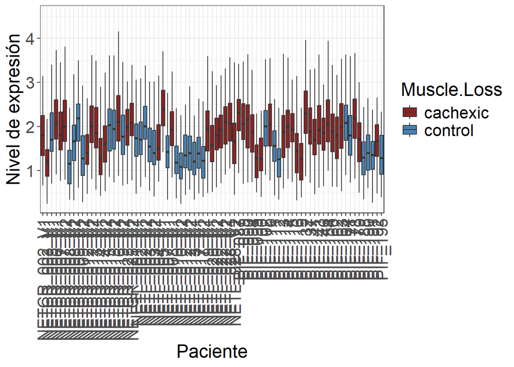

```r
#ggsave("Outputs/histogramas_expresion_trans.png", plot = histo_trans, width = 30, height = 25, dpi = 300)


# Se crea un boxplot tranformado para comparar los niveles de expresión por paciente
(boxplot1 <- ggplot(dataframe, aes(x = Patient_ID, y = log10(Expresión + 1), fill = `Muscle.loss`)) +
    geom_boxplot(outlier.shape = NA) +
    scale_fill_manual(values = c("cachexic" = "brown4", "control" = "steelblue")) +
    labs(x = "Paciente", y = "Nivel de expresión", fill = "Muscle.Loss")+
    theme_bw() +
    theme(
      axis.text.x = element_text(angle = 90, vjust = 0.5, hjust = 1, size = 16),
      axis.title.x = element_text(size = 18),
      axis.title.y = element_text(size = 18),
      axis.text.y = element_text(size = 16),
      legend.text = element_text(size = 16),
      legend.title = element_text(size = 18)))
```

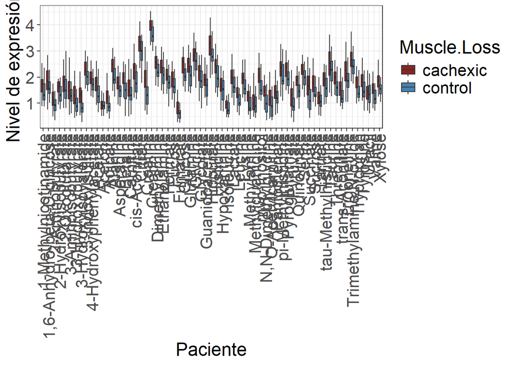

```r
#ggsave("Outputs/Boxplot_plot1.png", plot = boxplot1, width = 25, height = 15, dpi = 300)


# Se crea un boxplot tranformado para comparar los niveles de expresión por metabolito
(boxplot2 <- ggplot(dataframe, aes(x = Metabolito, y = log10(Expresión + 1), fill = `Muscle.loss`)) +
    geom_boxplot(outlier.shape = NA) +
    scale_fill_manual(values = c("cachexic" = "brown4", "control" = "steelblue")) +
    labs(x = "Paciente", y = "Nivel de expresión", fill = "Muscle.Loss")+
    theme_bw() +
    theme(
      axis.text.x = element_text(angle = 90, vjust = 0.5, hjust = 1, size = 16),
      axis.title.x = element_text(size = 18),
      axis.title.y = element_text(size = 18),
      axis.text.y = element_text(size = 16),
      legend.text = element_text(size = 16),
      legend.title = element_text(size = 18)))
```

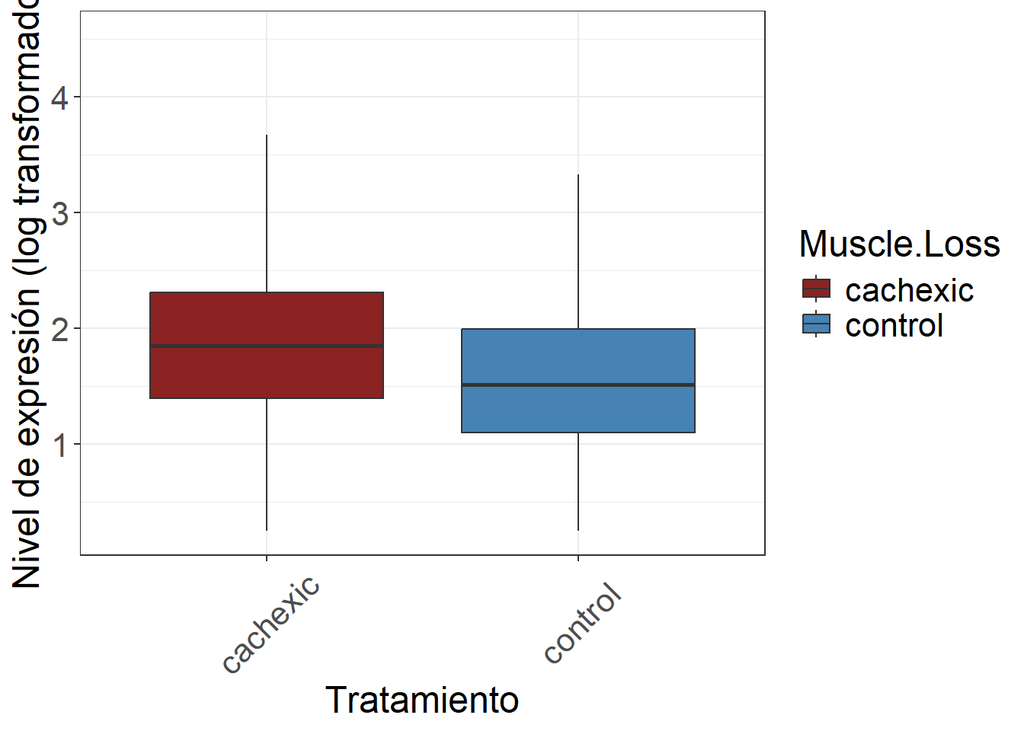

```r
#ggsave("Outputs/Boxplot_plot2.png", plot = boxplot2, width = 20, height = 15, dpi = 300)


# Se crea un boxplot tranformado para comparar los niveles de expresión por afección de caquexia o no
(boxplot3 <- ggplot(dataframe, aes(x = `Muscle.loss`, y = log10(Expresión + 1), fill = `Muscle.loss`)) +
    geom_boxplot(outlier.shape = NA) +
    scale_fill_manual(values = c("cachexic" = "brown4", "control" = "steelblue")) +
    labs(x = "Tratamiento", y = "Nivel de expresión (log transformado)", fill = "Muscle.Loss") +
    theme_bw() +
    theme(
      axis.text.x = element_text(angle = 45, vjust = 0.5, hjust = 0.5, size = 16),
      axis.title.x = element_text(size = 18),
      axis.title.y = element_text(size = 18),
      axis.text.y = element_text(size = 16),
      legend.text = element_text(size = 16),
      legend.title = element_text(size = 18)
    ))
```

```r
#ggsave("Outputs/Boxplot_plot3.png", plot = boxplot3, width = 20, height = 15, dpi = 300)
```

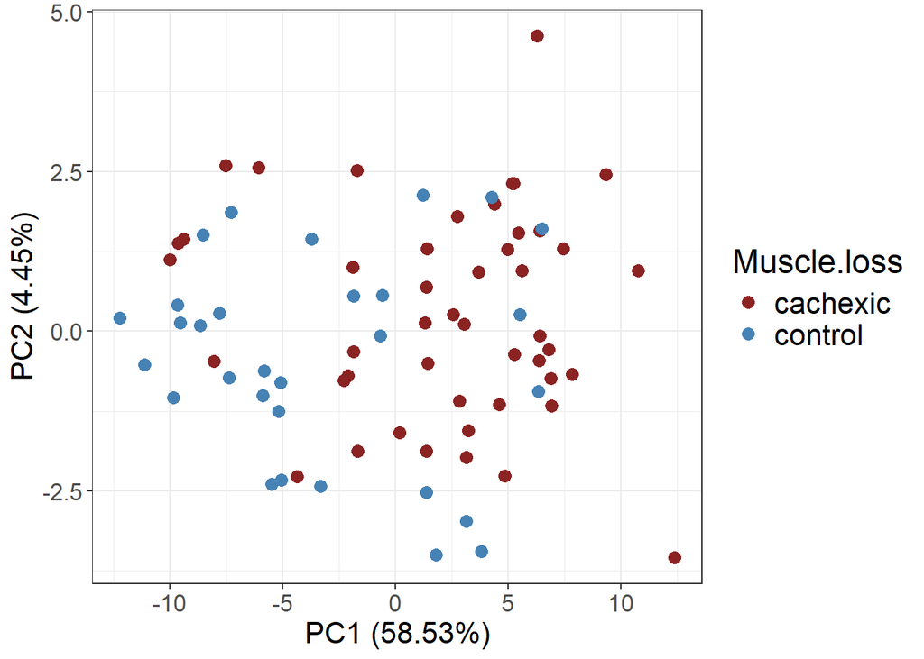

```r
# Análisis multivariante

#Para visualizar como los pacientes se agrupan espacialmente en función de sus niveles de expresión de metabolitos se realiza una PCA.

# Realizar PCA sobre los datos de expresión de metabolitos
log_counts <- log10(t(assay(se_object, "counts")) + 1) #transformo los datos con el logaritmo en base 10.

pca_res_log <- prcomp(log_counts, scale. = TRUE) # se obtiene las coordenadas de cada PC por metabolito

# Extraer las coordenadas de los primeros dos componentes principales (PC1 y PC2)
pca_df <- as.data.frame(pca_res_log$x)  # Esto extrae la x(coordenadas de PC) y convierte las coordenadas en dataframe
pca_df$Muscle.loss <- colData(se_object)$`Muscle loss`  # Se añade la columna de metadatos (Muscle.loss)

# Extraer las coordenadas de los metabolitos
pca_var <- as.data.frame(pca_res_log$rotation[, 1:2]) #  extrae las columnas del PC1 y PC2 y lo convierte en dataframe
pca_var$Metabolito <- rownames(pca_var)  # Añade una columna con los nombres de metabolitos


## Determinar el porcentaje de variación explicado por cada PC.
std_devs <- pca_res_log$sdev # extrae los desviación estándar del objeto pca_res_log
eigenvalues <- std_devs^2 # cálculo para obtener la varianza.
variance_explained <- eigenvalues / sum(eigenvalues)
cumulative_variance <- cumsum(variance_explained) # porcentaje de variación explicada por los PC.

# PCA del PC1 y Pc2

(pca_plot_v1 <- ggplot(pca_df, aes(x = PC1, y = PC2, colour = Muscle.loss)) +
    geom_point(size = 3) +
    scale_colour_manual(values = c("cachexic" = "brown4", "control" = "steelblue")) +
    labs(x = "PC1 (58.53%)",y = "PC2 (4.45%)") +
    theme_bw() +
    theme(text = element_text(size = 16),
          legend.title = element_text(size = 18),
          legend.text = element_text(size = 16)))
```

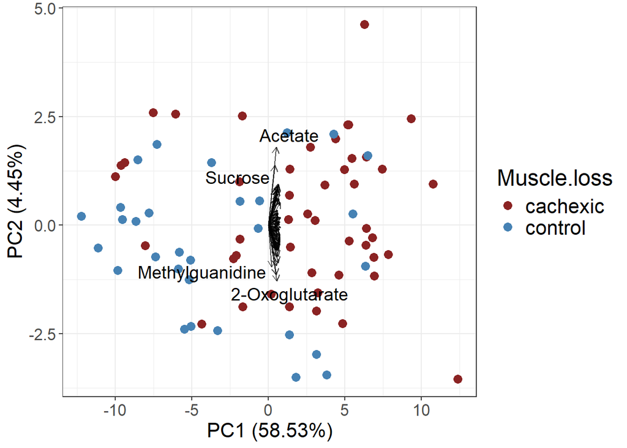

```r
#ggsave("Outputs/pca_plot_v1.png", plot = pca_plot_v1, width = 15, height = 8, dpi = 300)


# PCA añadiendo las coordenadas de los metabolitos
(pca_plot_v2 <- ggplot() +
    geom_point(data = pca_df, aes(x = PC1, y = PC2, colour = Muscle.loss), size = 3) +
    scale_colour_manual(values = c("cachexic" = "brown4", "control" = "steelblue")) +
    geom_segment(data = pca_var, aes(x = 0, y = 0, xend = PC1 * 5, yend = PC2 * 5),     # Flechas de los metabolitos
                 arrow = arrow(length = unit(0.2, "cm")), color = "black", alpha = 0.7) +
    geom_text_repel(data = pca_var, aes(x = PC1 * 5, y = PC2 * 5, label = Metabolito),
                    size = 5, color = "black", max.overlaps = 20) +     # Etiquetas de los metabolitos
    labs(x = "PC1 (58.53%)",
         y = "PC2 (4.45%)") +
    theme_bw() +
    theme(text = element_text(size = 16),
          legend.title = element_text(size = 18),
          legend.text = element_text(size = 16)))
```

```r
#ggsave("Outputs/pca_plot_v2.png", plot = pca_plot_v2, width = 15, height = 8, dpi = 300)
```